# Activity tracking exercise quality

Antti Loukiala

03/26/2016

# Abstract

Activity trackers give great amount of data about the movement of the subject, but for now very little about the quality of the movement. In this paper we study the quality of the movement by using a data recorded during weightlifting. With the data the quality can be estimated with fairly good accuracy, even with reasonable amount of data points.

# Data

There are various amount of data points for the measuring. The data can be grouped into four different groups, arms, forearms, belt and dumbbell. Each of the group consists of different type of measures, combined to give a idea of how the subject in study is moving. Lot of the sensors give very little data and those ones can be discarded right away.

```r
setwd("/home/antti/Desktop/DataScience/PracticalMachineLearning")
d = read.csv("pml-training.csv")

## From here we can see what data we have
str(d)
## From here we can see the amount of values in measures
summary(d)
library(dplyr)
predictors <- dplyr::select(d,
                     roll_belt, pitch_belt, yaw_belt,
                     total_accel_belt,
                     gyros_belt_x, gyros_belt_y, gyros_belt_z,
                     accel_belt_x, accel_belt_y, accel_belt_z,
                     magnet_belt_x, magnet_belt_y, magnet_belt_z,
                     roll_arm, pitch_arm, yaw_arm, total_accel_arm,
                     total_accel_arm,
                     gyros_arm_x, gyros_arm_y, gyros_arm_z,
                     accel_arm_x, accel_arm_y, accel_arm_z,
                     magnet_arm_x, magnet_arm_y, magnet_arm_z,
                     roll_dumbbell, pitch_dumbbell, yaw_dumbbell,
                     total_accel_dumbbell,
                     gyros_dumbbell_x, gyros_dumbbell_y, gyros_dumbbell_z,
                     accel_dumbbell_x, accel_dumbbell_y, accel_dumbbell_z,
                     magnet_dumbbell_x, magnet_dumbbell_y, magnet_dumbbell_z,
                     roll_forearm, pitch_forearm, yaw_forearm,
                     total_accel_forearm,
                     gyros_forearm_x, gyros_forearm_y, gyros_forearm_z,
                     accel_forearm_x, accel_forearm_y, accel_forearm_z,
                     magnet_forearm_x, magnet_forearm_y, magnet_forearm_z)
bel <- dplyr::select(d, roll_dumbbell, pitch_dumbbell, yaw_dumbbell,
                     total_accel_dumbbell,
                     gyros_dumbbell_x, gyros_dumbbell_y, gyros_dumbbell_z,
                     accel_dumbbell_x, accel_dumbbell_y, accel_dumbbell_z,
                     magnet_dumbbell_x, magnet_dumbbell_y, magnet_dumbbell_z)
totals <- dplyr::select(d, total_accel_belt, total_accel_arm, total_accel_dumbbell, total_accel_forearm)

# dumbbell correlation on itself
cor(bel)
```

[output not shown]

Lot of the sensors measure the same thing. For example, there is a high correlation in total acceleration of arms and the acceleration in three dimensions. Therefore we will begin by using only the total data.

# The model

Since we are measuring weightlifting, a good quality movement should be steady all the way. With this idea, the total acceleration can be considered a good indicator in a domain sense. Another one is the dumbbell. The weight should move in a steady fashion for a the duration of the excersice. The model will be build by using random forest for its general use in machine learning.

```r
library(dplyr)
library(caret)
totalsDumb <- dplyr::select(d, total_accel_belt, total_accel_arm, total_accel_dumbbell,
                            total_accel_forearm,
                            roll_dumbbell, pitch_dumbbell, yaw_dumbbell,
                            classe)

set.seed(1)
trainingContr <- trainControl(method = "cv", number = 4)

model <- train(totalsDumb$classe ~ ., method = "rf", trControl = trainingContr,
    totalsDumb)
```

```r
# Summary of the model and the plot of accuracies
summary(model)
```

```
##                 Length Class      Mode
## call                4  -none-     call
## type                1  -none-     character
## predicted       19622  factor     numeric
## err.rate         3000  -none-     numeric
## confusion          30  -none-     numeric
## votes           98110  matrix     numeric
## oob.times       19622  -none-     numeric
## classes             5  -none-     character
## importance          7  -none-     numeric
## importanceSD        0  -none-     NULL
## localImportance     0  -none-     NULL
## proximity           0  -none-     NULL
## ntree               1  -none-     numeric
## mtry                1  -none-     numeric
## forest             14  -none-     list
## y               19622  factor     numeric
## test                0  -none-     NULL
## inbag               0  -none-     NULL
## xNames              7  -none-     character
## problemType         1  -none-     character
## tuneValue           1  data.frame list
## obsLevels           5  -none-     character
```

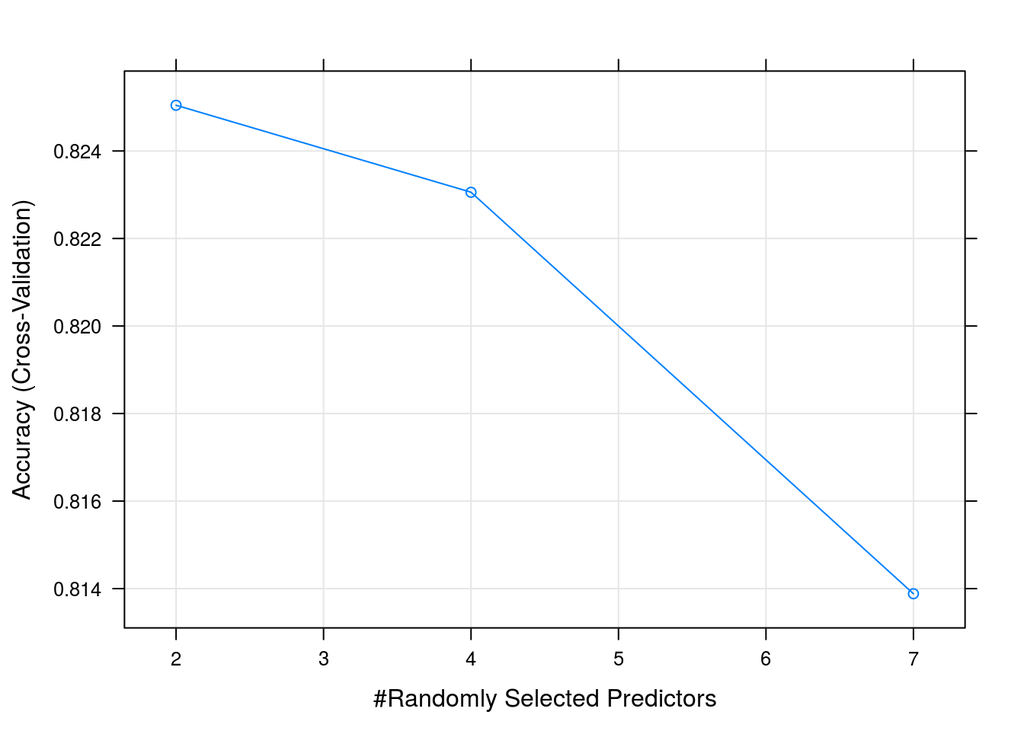

```r
plot(model)
```

```r
# Average of the accuracy
mean(model[[4]]$Accuracy)
```

```
## [1] 0.8206613
```

Estimate of the out of sample error is 18 %. (1-accuracy * 100).

# Output

The data is a measurements recorded from a sensor of subjects doing weightlifting exercise. With the data we can give fairly good estimate of how well the subject is training. The model build in this paper uses idea of following the weight trough out the movement. The model can be kept fairly simple and achieve good results, making it reasonable to be used in real life applications as well. The accuracy can be improved for sure, but for the simplicity, the achieved accuracy can be considered a good one.